# R Notebook

Ashley Fairley  
03/2021

## KNN and Naive Bayes Classifiers

### Applying k-Nearest Neighbors to Predict Income

**Data Exploration:**

**Download the dataset, change the header names, and trim the white space:**

```r
adult <- read.table("adult.data", header = FALSE, sep = ",", strip.white = TRUE, na.string = "?")

colnames(adult) <-c("age", "workclass", "final_weight", "education", "years_education", "marital_status", "occupation", "family_role", "ethnicity", "gender", "investment_gain", "investment_loss", "hours_per_week", "native_country", "income")
```

**Explore the overall structure of the dataset and get a summary of statistics for each variable. Are there any missing values?**

There are six numeric variables and nine categorical variables. There are 4,262 entries listed as NA/missing values (originally indicated with a ‘?’).

```r
str(adult)
```

```
## 'data.frame':    32561 obs. of  15 variables:
##  $ age            : int  39 50 38 53 28 37 49 52 31 42 ...
##  $ workclass      : chr  "State-gov" "Self-emp-not-inc" "Private" "Private" ...
##  $ final_weight   : int  77516 83311 215646 234721 338409 284582 160187 209642 45781 159449 ...
##  $ education      : chr  "Bachelors" "Bachelors" "HS-grad" "11th" ...
##  $ years_education: int  13 13 9 7 13 14 5 9 14 13 ...
##  $ marital_status : chr  "Never-married" "Married-civ-spouse" "Divorced" "Married-civ-spouse" ...
##  $ occupation     : chr  "Adm-clerical" "Exec-managerial" "Handlers-cleaners" "Handlers-cleaners" ...
##  $ family_role    : chr  "Not-in-family" "Husband" "Not-in-family" "Husband" ...
##  $ ethnicity      : chr  "White" "White" "White" "Black" ...
##  $ gender         : chr  "Male" "Male" "Male" "Male" ...
##  $ investment_gain: int  2174 0 0 0 0 0 0 0 14084 5178 ...
##  $ investment_loss: int  0 0 0 0 0 0 0 0 0 0 ...
##  $ hours_per_week : int  40 13 40 40 40 40 16 45 50 40 ...
##  $ native_country : chr  "United-States" "United-States" "United-States" "United-States" ...
##  $ income         : chr  "<=50K" "<=50K" "<=50K" "<=50K" ...
```

```r
summary(adult)
```

```
##       age         workclass          final_weight      education
##  Min.   :17.00   Length:32561       Min.   :  12285   Length:32561
##  1st Qu.:28.00   Class :character   1st Qu.: 117827   Class :character
##  Median :37.00   Mode  :character   Median : 178356   Mode  :character
##  Mean   :38.58                      Mean   : 189778
##  3rd Qu.:48.00                      3rd Qu.: 237051
##  Max.   :90.00                      Max.   :1484705
##  years_education marital_status      occupation        family_role
##  Min.   : 1.00   Length:32561       Length:32561       Length:32561
##  1st Qu.: 9.00   Class :character   Class :character   Class :character
##  Median :10.00   Mode  :character   Mode  :character   Mode  :character
##  Mean   :10.08
##  3rd Qu.:12.00
##  Max.   :16.00
##   ethnicity            gender          investment_gain investment_loss
##  Length:32561       Length:32561       Min.   :    0   Min.   :   0.0
##  Class :character   Class :character   1st Qu.:    0   1st Qu.:   0.0
##  Mode  :character   Mode  :character   Median :    0   Median :   0.0
##                                        Mean   : 1078   Mean   :  87.3
##                                        3rd Qu.:    0   3rd Qu.:   0.0
##                                        Max.   :99999   Max.   :4356.0
##  hours_per_week  native_country        income
##  Min.   : 1.00   Length:32561       Length:32561
##  1st Qu.:40.00   Class :character   Class :character
##  Median :40.00   Mode  :character   Mode  :character
##  Mean   :40.44
##  3rd Qu.:45.00
##  Max.   :99.00
```

```r
sum(is.na(adult))
```

```
## [1] 4262
```

**Get the frequency table of the “income” variable. Is the data balanced?**

The table is unbalanced. <=50K comprises approximately 76% of entries (>50K approximately 24%).

```r
sum(is.na(adult$income))
```

```
## [1] 0
```

```r
table(adult$income)
```

```
##
## <=50K  >50K
## 24720  7841
```

**Explore the data in order to investigate the association between income & other features. Which features seem most likely to be useful in predicting income?**

```r
i <- (adult$income)
options(scipen = 999)
library(gmodels)
```

*Numeric variables:*

- age: using t.test(), I found the p-value to be less than 0.01 (p-value < 0.00000000000000022), and therefore assume a correlation between age & income.
- final_weight: using t.test(), there does not appear to be a correlation. p-value = 0.08167 > 0.01 & 0.05
- years_education: The p-value is less than 0.01 (p-value < 0.00000000000000022), therefore I conclude a correlation between years of education & income.
- investment_gain: I conclude a correlation between investment gains & income. p-value < 0.00000000000000022
- investment_loss: Similarly to gains, I conclude a correlation between investment losses and income. p-value < 0.00000000000000022
- hours_per_week: The p-value is less than 0.01 (p-value < 0.00000000000000022) and so I again conclude that there is a correlation between hours worked per week and income.

```
t.test(adult$age~i)
t.test(adult$final_weight~i)
t.test(adult$years_education~i)
t.test(adult$investment_gain~i)
t.test(adult$investment_loss~i)
t.test(adult$hours_per_week~i)
```

*Categorical variables:*

- workclass: The p-value is well below 0.01, therefore I conclude a correlation exists between work class & income.
- education: P = 0, so I conclude a correlation between education and income.
- marital_status: Again, p = 0, so I am concluding a correlation between marital status and income.
- occupation: P = 0; I conclude there is a correlation between occupation & income.
- family_role: P = 0, I conclude there is a correlation between family role and income.
- ethnicity: The p-value is well below 0.01. I conclude there is a correlation between ethnicity & income.
- gender: Again the p-value = 0, so it is impossible that there is not a correlation between income and gender.
- native_country: The p-value is well below 0.01, therefore I conclude there is strong evidence for correlation between native country and income.

```
CrossTable(adult$workclass, i, chisq = TRUE)
CrossTable(adult$education, i, chisq = TRUE)
CrossTable(adult$marital_status, i, chisq = TRUE)
CrossTable(adult$occupation, i, chisq = TRUE)
CrossTable(adult$family_role, i, chisq = TRUE)
CrossTable(adult$ethnicity, i, chisq = TRUE)
CrossTable(adult$gender, i, chisq = TRUE)
CrossTable(adult$native_country, i, chisq = TRUE)
```

For all variables excepting ‘final_weight’, I conclude that we must reject the null hypothesis and that there is a correlation between the variables and ‘income’. I also found an undeniable correlation between the variable ‘gender’ and the variables ‘family_role’, ‘occupation’, & ‘marital_status’ due to the p-value being zero. However, females are underrepresented in the dataset./

I will remove the following attributes:

- **final_weight**: There is not a correlation and it is not relevant other than being representative of the number of people in the census.
- **education**: This is numerically represented by ‘years_education’ and knn works better with numeric variables.
- **family_role**: This feature can be represented by other features, such as ‘marital_status’ and has a direct correlation to ‘gender’ so I feel it is redundant.
- **investment_gain**: There is a correlation with ‘income’, but I believe ‘income’ is the predictor and not vice versa.
- **investment_loss**: Same as ‘investment_gain’.

```r
adult <- adult[-c(3:4, 8, 11:12)]
str(adult)
```

```
## 'data.frame':    32561 obs. of  10 variables:
##  $ age            : int  39 50 38 53 28 37 49 52 31 42 ...
##  $ workclass      : chr  "State-gov" "Self-emp-not-inc" "Private" "Private" ...
##  $ years_education: int  13 13 9 7 13 14 5 9 14 13 ...
##  $ marital_status : chr  "Never-married" "Married-civ-spouse" "Divorced" "Married-civ-spouse" ...
##  $ occupation     : chr  "Adm-clerical" "Exec-managerial" "Handlers-cleaners" "Handlers-cleaners" ...
##  $ ethnicity      : chr  "White" "White" "White" "Black" ...
##  $ gender         : chr  "Male" "Male" "Male" "Male" ...
##  $ hours_per_week : int  40 13 40 40 40 40 16 45 50 40 ...
##  $ native_country : chr  "United-States" "United-States" "United-States" "United-States" ...
##  $ income         : chr  "<=50K" "<=50K" "<=50K" "<=50K" ...
```

**Data Preparation:**

**Change the “?” characters that representative of null values to NA:**

I did this when I loaded the datatset using na.string:

```
adult <- read.table("adult.data", header = FALSE, sep = ",", strip.white = TRUE, na.string = "?")
```

**Find the number of missing values in each column:**

There are three columns with missing values: - workclass (1836) - occupation (1843) - native_county (583)

```r
colSums(is.na(adult))
```

```
##             age       workclass years_education  marital_status      occupation
##               0            1836               0               0            1843
##       ethnicity          gender  hours_per_week  native_country          income
##               0               0               0             583               0
```

```r
findmode <- function(x) {
     ux <- unique(x)
     ux[which.max(tabulate(match(x, ux)))]
}

findmode(adult$workclass)
```

```
## [1] "Private"
```

```r
findmode(adult$occupation)
```

```
## [1] "Prof-specialty"
```

```r
findmode(adult$native_country)
```

```
## [1] "United-States"
```

```r
adult[is.na(adult)] <- findmode(adult[!is.na(adult)])
colSums(is.na(adult))
```

```
##             age       workclass years_education  marital_status      occupation
##               0               0               0               0               0
##       ethnicity          gender  hours_per_week  native_country          income
##               0               0               0               0               0
```

**Dealing with categorical values using one-hot-encoding:**

In order to do one-hot-encoding, I converted the categorical variables (except ‘income’) to a factor and converted to a data.table. Once converted back to a data.frame, I then factored the ‘income’ variable. I factored ‘income’ last to prevent it from being one-hot encoded.

```r
library(data.table)
library(mltools)

adult$workclass <- factor(adult$workclass)
adult$marital_status <- factor(adult$marital_status)
adult$occupation <- factor(adult$occupation)
adult$ethnicity <- factor(adult$ethnicity)
adult$gender <- factor(adult$gender)
adult$native_country <- factor(adult$native_country)

adult_t <- as.data.table(adult)
adult_t <- one_hot(adult_t, cols = "auto", dropCols = TRUE, dropUnusedLevels = TRUE)
adult <- as.data.frame(adult_t)
adult$income <- factor(adult$income)
```

**Training and Evaluation of ML Models:**

**Set the seed of the random number generator to a fixed integer:**

```r
set.seed(1)
```

**Scale all numeric features using Min-Max Scaling:**

Normalizing the numeric attributes with min-max scaling by writing a min-max function:

```r
min_max <- function(x) {
  return ((x-min(x)) / (max(x)-min(x)))
}

adult$age <- min_max(adult$age)
adult$years_education <- min_max(adult$years_education)
adult$hours_per_week <- min_max(adult$hours_per_week)
```

**Randomize Order of Rows:**

```r
adult <- adult[sample(nrow(adult), replace = FALSE), ]
```

**Use 5-fold cross validation with KNN to predict the “income” variable and report the cross-validation error:"**

Using the 5-fold cross-validation error function (k = sqrt(n)), we find the estimate of knn error on the ‘income’ data to be 0.1673782.

```r
library(class)
library(caret)
adult_train <- adult[1:26048, -83]
adult_test <- adult[26049:32561, -83]
adult_train_labels <- adult[1:26048, 83]
adult_test_labels <- adult[26049:32561, 83]

adult_test_pred <- knn(train = adult_train, test = adult_test, cl = adult_train_labels, k = 180)

CrossTable(x = adult_test_labels, y = adult_test_pred, prop.chisq = FALSE)
```

```
##
##
##    Cell Contents
## |-------------------------|
## |                       N |
## |           N / Row Total |
## |           N / Col Total |
## |         N / Table Total |
## |-------------------------|
##
##
## Total Observations in Table:  6513
##
##
##                   | adult_test_pred
## adult_test_labels |     <=50K |      >50K | Row Total |
## ------------------|-----------|-----------|-----------|
##             <=50K |      4558 |       398 |      4956 |
##                   |     0.920 |     0.080 |     0.761 |
##                   |     0.867 |     0.317 |           |
##                   |     0.700 |     0.061 |           |
## ------------------|-----------|-----------|-----------|
##              >50K |       700 |       857 |      1557 |
##                   |     0.450 |     0.550 |     0.239 |
##                   |     0.133 |     0.683 |           |
##                   |     0.107 |     0.132 |           |
## ------------------|-----------|-----------|-----------|
##      Column Total |      5258 |      1255 |      6513 |
##                   |     0.807 |     0.193 |           |
## ------------------|-----------|-----------|-----------|
##
##
```

```r
folds = createFolds(adult$income, k = 5)
str(folds)
```

```
## List of 5
##  $ Fold1: int [1:6512] 1 2 5 10 13 18 25 33 38 39 ...
##  $ Fold2: int [1:6513] 3 6 19 21 23 49 55 58 62 66 ...
##  $ Fold3: int [1:6512] 7 8 16 17 20 24 28 31 35 36 ...
##  $ Fold4: int [1:6512] 4 11 12 22 26 27 29 30 37 46 ...
##  $ Fold5: int [1:6512] 9 14 15 32 34 44 56 64 71 76 ...
```

```r
knn_fold = function(features, target, fold, k) {
  train = features[-fold,]
  validation = features[fold,]
  train_labels = target[-fold]
  validation_labels = target[fold]
  validation_preds = knn(train, validation, train_labels, k = k)
  t = table(validation_labels, validation_preds)
  error = (t[1,2] + t[2,1])/(t[1,1] + t[1,2] + t[2,1] + t[2,2])
  return(error)
}

crossValidationError = function(features, target, k) {
  folds = createFolds(target, k = 5)
  errors = sapply(folds, knn_fold, features = features, target = target, k = k)
  return (mean(errors))
}

crossValidationError(adult[,-83], adult[,83], 180)
```

```
## [1] 0.1673782
```

**Tune K by trying different values:**

```r
ks <- c(1, 5, 10, 20, 50, 100, 180)
errors <- sapply(ks, crossValidationError, features = adult[,-83], target = adult[,83])
errors
```

```
## [1] 0.2120635 0.1803383 0.1701728 0.1651361 0.1644606 0.1660884 0.1675011
```

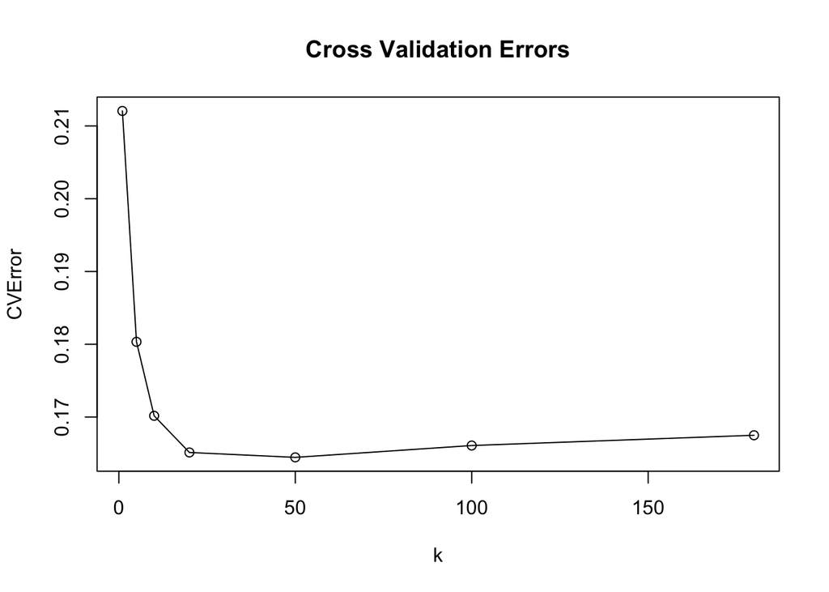

```r
plot(errors~ks, main="Cross Validation Errors", xlab="k", ylab="CVError")
lines(errors~ks)
```

Results: - *k = 1:* 0.2120635 - *k = 5:* 0.1803383 - *k = 10:* 0.1701728 - *k = 20:* 0.1651361 - *k = 50:* 0.1644606 - *k = 100:* 0.1660884 - *k = sqrt(n) = 180(floor):* 0.1675011

K = 50 provides the lowest cross-validation error.

**Use 5-fold cross validation with KNN to predict the income variable and report the average false positive rate (FPR) and false negative rate (FNR) of the classifier:**

```r
false_knn_fold = function(features, target, fold, k) {
  train = features[-fold,]
  validation = features[fold,]
  train_labels = target[-fold]
  validation_labels = target[fold]
  validation_preds = knn(train, validation, train_labels, k = 5)
  t = table(validation_labels, validation_preds)
  FPR = t[1,2]/(t[1,2]+t[1,1])
  FNR = t[2,1]/(t[2,1]+t[2,2])
  return (c("FPR"=FPR, "FNR"=FNR))
}

false_crossValidationError = function(features, target, k) {
  folds = createFolds(target, k = 5)
  errors = sapply(folds, false_knn_fold, features = features, target = target, k = 5)
  return (rowMeans(errors))
}

false_errors <- false_crossValidationError(adult[,-83], adult[,83], 50)

false_errors
```

```
##       FPR       FNR
## 0.1036812 0.4212467
```

### Applying Naive Bayes Classifier to Predict Income

**Set the seed:**

```
set.seed(1)
```

**Decide which features to keep and which to remove:**

For Problem 2, I am reading the dataset in, changing column names, and imputing the missing values as was done for Problem 1:

```r
nb_adult <- read.table("adult.data", header = FALSE, sep = ",", strip.white = TRUE, na.string = "?", stringsAsFactors = FALSE)

colnames(nb_adult) <-c("age", "workclass", "final_weight", "education", "years_education", "marital_status", "occupation", "family_role", "ethnicity", "gender", "investment_gain", "investment_loss", "hours_per_week", "native_country", "income")

nb_adult[is.na(nb_adult)] <- findmode(nb_adult[!is.na(nb_adult)])
```

Similarly to Problem 1, I will remove ‘final_weight’, ‘investment_gain’, ‘investment_loss’, and ‘family_role’, but instead of removing ‘education’ - I will remove ‘years_education’ instead. This is because Naive Bayes doesn’t work with numerical values. I then convert the existing numerical columns to categorical variables.

```r
nb_adult <- nb_adult[-c(3, 5, 8, 11:12)]

age_bp <- c(-Inf, 19, 29, 39, 49, 59, 69, 79, Inf)
labels_age_bp <- c("15-19", "20-29", "30-39", "40-49", "50-59", "60-69", "70-79", "80+")
nb_adult$age <- cut(nb_adult$age, breaks = age_bp, labels = labels_age_bp)

hours_bp <- c(-Inf, 35, 45, Inf)
labels_hours_bp <- c("Part-Time", "Full-Time", "Over-Time")
nb_adult$hours_per_week <- cut(nb_adult$hours_per_week, breaks = hours_bp, labels = labels_hours_bp)

nb_adult$workclass <- factor(nb_adult$workclass)
nb_adult$education <- factor(nb_adult$education)
nb_adult$marital_status <- factor(nb_adult$marital_status)
nb_adult$occupation <- factor(nb_adult$occupation)
nb_adult$ethnicity <- factor(nb_adult$ethnicity)
nb_adult$gender <- factor(nb_adult$gender)
nb_adult$native_country <- factor(nb_adult$native_country)
nb_adult$income <- factor(nb_adult$income)

str(nb_adult)
```

```
## 'data.frame':    32561 obs. of  10 variables:
##  $ age           : Factor w/ 8 levels "15-19","20-29",..: 3 5 3 5 2 3 4 5 3 4 ...
##  $ workclass     : Factor w/ 9 levels "   0","Federal-gov",..: 8 7 5 5 5 5 5 7 5 5 ...
##  $ education     : Factor w/ 16 levels "10th","11th",..: 10 10 12 2 10 13 7 12 13 10 ...
##  $ marital_status: Factor w/ 7 levels "Divorced","Married-AF-spouse",..: 5 3 1 3 3 3 4 3 5 3 ...
##  $ occupation    : Factor w/ 15 levels "   0","Adm-clerical",..: 2 5 7 7 11 5 9 5 11 5 ...
##  $ ethnicity     : Factor w/ 5 levels "Amer-Indian-Eskimo",..: 5 5 5 3 3 5 3 5 5 5 ...
##  $ gender        : Factor w/ 2 levels "Female","Male": 2 2 2 2 1 1 1 2 1 2 ...
##  $ hours_per_week: Factor w/ 3 levels "Part-Time","Full-Time",..: 2 1 2 2 2 2 1 2 3 2 ...
##  $ native_country: Factor w/ 42 levels "   0","Cambodia",..: 40 40 40 40 6 40 24 40 40 40 ...
##  $ income        : Factor w/ 2 levels "<=50K",">50K": 1 1 1 1 1 1 1 2 2 2 ...
```

```r
library(e1071)
library(caret)
```

**Use 5-fold cross validation with Naive Bayes to predict the “income” variable and report the cross-validation error:**

```r
nb_adult <- nb_adult[sample(nrow(nb_adult), replace = FALSE), ]

nb_adult_train <- nb_adult[1:26048, -10]
nb_adult_test <- nb_adult[26049:32561, -10]
nb_adult_train_labels <- nb_adult[1:26048, 10]
nb_adult_test_labels <- nb_adult[26049:32561, 10]

nb_classifier <- naiveBayes(nb_adult_train, nb_adult_train_labels)
nb_adult_test_pred <- predict(nb_classifier, nb_adult_test)

CrossTable(nb_adult_test_pred, nb_adult_test_labels, prop.chisq = FALSE, prop.t = FALSE, dnn = c('predicted', 'actual'))
```

```
##
##
##    Cell Contents
## |-------------------------|
## |                       N |
## |           N / Row Total |
## |           N / Col Total |
## |-------------------------|
##
##
## Total Observations in Table:  6513
##
##
##              | actual
##    predicted |     <=50K |      >50K | Row Total |
## -------------|-----------|-----------|-----------|
##        <=50K |      4208 |       487 |      4695 |
##              |     0.896 |     0.104 |     0.721 |
##              |     0.856 |     0.305 |           |
## -------------|-----------|-----------|-----------|
##         >50K |       710 |      1108 |      1818 |
##              |     0.391 |     0.609 |     0.279 |
##              |     0.144 |     0.695 |           |
## -------------|-----------|-----------|-----------|
## Column Total |      4918 |      1595 |      6513 |
##              |     0.755 |     0.245 |           |
## -------------|-----------|-----------|-----------|
##
##
```

```r
nb_folds <- createFolds(nb_adult$income, k = 5)

naiveBayes_fold = function(fold, features, target, laplace = 0) {
    train = features[-fold,]
    validation = features[fold,]
    train_labels = target[-fold]
    validation_labels = target[fold]
    NaiveBayes_model = naiveBayes(train, train_labels, laplace = laplace)
    validation_preds = predict(NaiveBayes_model, validation)
    t = table(validation_labels, validation_preds)
    error = (t[1,2] + t[2,1])/(t[1,1] + t[1,2] + t[2,1] + t[2,2])
    return(error)
}

nb_crossValidationError = function(features, target, laplace = 0, n_folds) {
  folds = createFolds(target, k = 5)
  errors = sapply(folds, naiveBayes_fold, features = features, target = target, laplace = laplace)
  return (mean(errors))
}
```

The cross-validation error:

```r
nb_crossValidationError(nb_adult[,-10], nb_adult[,10], 50)
```

```
## [1] 0.1851604
```

```
nb_errors <- sapply(ks, nb_crossValidationError, features = nb_adult[,-10], target = nb_adult[,10])
nb_errors
```

**Compare the cross validation error of Naive Bayes with that of KNN. Which performs better on this dataset?**

The cross-validation error using the KNN algorithm is 0.1673782, while the cross-validation algorithm using Naive Bayes classifier is 0.1851604. Therefore, I would say that KNN performs better on the adult dataset.

**Compare the False Positive Rate and False Negative Rate of Naive Bayes:**

```r
false_naiveBayes_fold = function(fold, features, target, laplace = 0) {
  train = features[-fold,]
  validation = features[fold,]
  train_labels = target[-fold]
  validation_labels = target[fold]
  NaiveBayes_model = naiveBayes(train, train_labels, laplace = laplace)
  validation_preds = predict(NaiveBayes_model, validation)
  t = table(validation_labels, validation_preds)
  FPR = t[1,2]/(t[1,2]+t[1,1])
  FNR = t[2,1]/(t[2,1]+t[2,2])
  return (c("FPR"=FPR, "FNR"=FNR))
}

false_nb_crossValidationError = function(features, target, laplace = 0, n_folds) {
  folds = createFolds(target, k = 5)
  errors = sapply(folds, false_naiveBayes_fold, features = features, target = target, laplace = laplace)
  return (rowMeans(errors))
}

nb_false_errors <- false_nb_crossValidationError(features = rbind(nb_adult_train, nb_adult_test), target = nb_adult$income, n_folds = 5)

nb_false_errors
```

```
##       FPR       FNR
## 0.1453479 0.3115673
```

```r
lc_errors <- false_nb_crossValidationError(features = rbind(nb_adult_train, nb_adult_test), target = nb_adult$income, n_folds=5, laplace = 1)

lc_errors
```

```
##       FPR       FNR
## 0.1458738 0.3127164
```

### Testing results with undersampling:

*Undersampling the Majority Class:*

Using undersampling and K tuned to 50 to balance the dataset, the KNN cross-validation error is 0.2035451 and the Naive Bayes cross-validation error is 0.2056501. Balancing the dataset through undersampling does not improve the CVE of this particular dataset.  
KNN:

```
undersampling <- read.table("adult.data", header = FALSE, sep = ",", strip.white = TRUE, na.string = "?")

colnames(undersampling) <-c("age", "workclass", "final_weight", "education", "years_education", "marital_status", "occupation", "family_role", "ethnicity", "gender", "investment_gain", "investment_loss", "hours_per_week", "native_country", "income")
undersampling <- undersampling[-c(3:4, 8, 11:12)]
undersampling[is.na(undersampling)] <- findmode(undersampling[!is.na(undersampling)])

less_fifty <- which(undersampling$income == "<=50K")
greater_fifty <- which(undersampling$income == ">50K")
nsamp <- 7841
pick_less <- sample(less_fifty, nsamp)
pick_greater <- sample(greater_fifty, nsamp)

new_under <- undersampling[c(pick_less, pick_greater), ]
table(new_under$income)

library(data.table)
library(mltools)

new_under$workclass <- factor(new_under$workclass)
new_under$marital_status <- factor(new_under$marital_status)
new_under$occupation <- factor(new_under$occupation)
new_under$ethnicity <- factor(new_under$ethnicity)
new_under$gender <- factor(new_under$gender)
new_under$native_country <- factor(new_under$native_country)

newUnder_t <- as.data.table(new_under)
newUnder_t <- one_hot(newUnder_t, cols = "auto", dropCols = TRUE, dropUnusedLevels = TRUE)
new_under <- as.data.frame(newUnder_t)

new_under$income <- factor(new_under$income)
new_under$age <- min_max(new_under$age)
new_under$years_education <- min_max(new_under$years_education)
new_under$hours_per_week <- min_max(new_under$hours_per_week)

set.seed(1)
new_under <- new_under[sample(nrow(new_under), replace = FALSE), ]

nu_train <- new_under[1:3136, -83]
nu_test <- new_under[3137:15682, -83]
nu_train_labels <- new_under[1:3136, 83]
nu_test_labels <- new_under[3137:15682, 83]

nu_test_pred <- knn(train = nu_train, test = nu_test, cl = nu_train_labels, k = 125)
CrossTable(x = nu_test_labels, y = nu_test_pred, prop.chisq = FALSE)

folds = createFolds(new_under$income, k = 5)

ks <- c(1, 5, 10, 20, 50, 100, 125)
nu_errors <- sapply(ks, crossValidationError, features = new_under[,-83], target = new_under[,83])
nu_errors

#[1] 0.2537301 0.2147046 0.2083915 0.2059692 0.2035451 0.2087107 0.2109426
```

Naive Bayes:

```
nb_under <- read.table("adult.data", header = FALSE, sep = ",", strip.white = TRUE, na.string = "?", stringsAsFactors = FALSE)

colnames(nb_under) <-c("age", "workclass", "final_weight", "education", "years_education", "marital_status", "occupation", "family_role", "ethnicity", "gender", "investment_gain", "investment_loss", "hours_per_week", "native_country", "income")
nb_under[is.na(nb_under)] <- findmode(nb_under[!is.na(nb_under)])
nb_under <- nb_under[-c(3, 5, 8, 11:12)]

nbless_fifty <- which(nb_under$income == "<=50K")
nbgreater_fifty <- which(nb_under$income == ">50K")
nsamp <- 7841
nbpick_less <- sample(nbless_fifty, nsamp)
nbpick_greater <- sample(nbgreater_fifty, nsamp)

nb_under <- nb_under[c(nbpick_less, nbpick_greater), ]
table(nb_under$income)

age_bp <- c(-Inf, 19, 29, 39, 49, 59, 69, 79, Inf)
labels_age_bp <- c("15-19", "20-29", "30-39", "40-49", "50-59", "60-69", "70-79", "80+")
nb_under$age <- cut(nb_under$age, breaks = age_bp, labels = labels_age_bp)

hours_bp <- c(-Inf, 35, 45, Inf)
labels_hours_bp <- c("Part-Time", "Full-Time", "Over-Time")
nb_under$hours_per_week <- cut(nb_under$hours_per_week, breaks = hours_bp, labels = labels_hours_bp)

nb_under$workclass <- factor(nb_under$workclass)
nb_under$education <- factor(nb_under$education)
nb_under$marital_status <- factor(nb_under$marital_status)
nb_under$occupation <- factor(nb_under$occupation)
nb_under$ethnicity <- factor(nb_under$ethnicity)
nb_under$gender <- factor(nb_under$gender)
nb_under$native_country <- factor(nb_under$native_country)
nb_under$income <- factor(nb_under$income)
library(e1071)
library(caret)

nb_under <- nb_under[sample(nrow(nb_under), replace = FALSE), ]

nb_under_train <- nb_under[1:3136, -10]
nb_under_test <- nb_under[3137:32561, -10]
nb_under_train_labels <- nb_under[1:3136, 10]
nb_under_test_labels <- nb_under[3137:32561, 10]

nb_u_classifier <- naiveBayes(nb_under_train, nb_under_train_labels)
nb_under_test_pred <- predict(nb_u_classifier, nb_under_test)

CrossTable(nb_under_test_pred, nb_under_test_labels, prop.chisq = FALSE, prop.t = FALSE, dnn = c('predicted', 'actual'))

nb_under_folds <- createFolds(nb_under$income, k = 5)
nb_crossValidationError(nb_under[,-10], nb_under[,10], 50)
#[1] 0.2056501
```